# Vignette 1 (Trunk Road Gritter Tracker)

Zhang ZhenYuan zzha315

## The Data

The [Trunk Road Gritter Tracker](https://www.arcgis.com/apps/webappviewer/index.html?id=2de764a9303848ffb9a4cac0bd0b1aab) is a web application published by [Transport Scotland](https://www.transport.gov.scot/our-approach/keep-scotland-moving/winter-service/) allowing the public to track the current road gritters in operation in Scotland, UK.

The webapp ([Trunk Road Gritter Tracker](https://www.arcgis.com/apps/webappviewer/index.html?id=2de764a9303848ffb9a4cac0bd0b1aab)) shows live tracking of the gritters on Scotland’s trunk road network. Displayed are the current locations of the gritters along with their historic trail.

## Web scraping

Firstly we need to know what is Web scraping. The purpose of Web scraping is to extract data we want from websites. Web scraping programme can directly access the world wide web by using hypertext transfer protocol or web browser. Although web scraping. can be done manually by software users, the term usually refers to automated processes using BOT or web scraper. It is a form of replication in which specific data is collected and copied from the Internet to a central local database or spreadsheet for later retrieval or analysis. Each webpage has a specific web address called Uniform Resource Locator(URL) and we can navigate to the web page by visiting the URL.

In short, a web page is composed of text, pictures, multimedia and other elements through artificial typesetting. Some of these elements are static elements, and some of them need to be obtained by sending HTTP requests from the client to the server. Therefore, when scraping web information, on the one hand, we can first locate the position of the desired element in the web page, and then acquire it, on the other hand, we can get what we want by getting the data returned by the HTTP request.

The `R` package we’ll be using to scrape the data is `jsonlite`, the raw data we get is represented in JSON format and `jsonlite` provides a simple and robust JSON parser and generator for R, we’ll use the `fromJSON` function in this package.

Install and load the packages:

```r
if(!require("jsonlite"))  {install.packages("jsonlite")}
library("jsonlite")
```

### Scraping the current locations

Opening the [Trunk Road Gritter Tracker](https://www.arcgis.com/apps/webappviewer/index.html?id=2de764a9303848ffb9a4cac0bd0b1aab) webpage we see each gritter shown by coloured symbols: yellow represents the operational gritters, grey represents those not currently operating. When we click on a gritter, the information about this gritter will pop up. All the gritters information is stored in a attribute table, which can be opened by clicking the white triangle button at the bottom of the page.

[figure not shown]

Screenshot for the web Page after openning the attribute table

Each gritter has 5 attributes:

- **Vehicle**, the unique registration number for the gritter,
- **Age (range)**, how long the trail of the gritter has been recorded,
- **Source Date**, the date when the trail of the gritter starts to be recorded
- **Source Datetime**, the exact time of the source date that the trail of the gritter starts to be recorded, and
- **Gritter Name**, the specific name of the gritter (e.g., Gritney Spears); it should be noted that not all gritters have given name.

Now, take Google Chrome as an example, navigate to this webpage and press F12 button and then go to the network tab. When we click to open the attribute table for current vehicle location, the page makes two GET xhr request to get the content we see after clicking the button. The first request will return the total number of gritters information and the second request will get all the attribute data we needed. We will import `httr` and `jsonlite` packages to parse the response. We use a variable to store the link address of the second GET request. `fromJson()` function in `jsonlite` package can help us to convert JSON data to R objects, after this, we can get the nested list that contains data we want to get.

We can get the data in attribute table by visiting the link address of the second GET xhr request that appears when we open the table. The data is in JSON format so We use `fromJson()` function in `jsonlite` package to convert JSON data to R objects.`flatten = TRUE` option allows us to flatten nested data frames into a regular 2 dimensional tabular structure.

```r
attribute_url = "https://services2.arcgis.com/ppIFLOeUcdFMQzkH/arcgis/rest/services/TSWT_VehiclesAndTrail_2020/FeatureServer/0/query?f=json&where=1%3D1&returnGeometry=true&spatialRel=esriSpatialRelIntersects&geometry=%7B%22xmin%22%3A-516646.2960923321%2C%22ymin%22%3A635046.1250484672%2C%22xmax%22%3A588996.3495111631%2C%22ymax%22%3A1174443.530519488%2C%22spatialReference%22%3A%7B%22wkid%22%3A27700%2C%22latestWkid%22%3A27700%7D%7D&geometryType=esriGeometryEnvelope&inSR=27700&outFields=*&orderByFields=OBJECTID%20ASC&outSR=27700"
attribute_json = fromJSON((attribute_url), flatten = TRUE)
```

The object `attribute_json` is a list which contains 7 elements:

```r
length(attribute_json)
```

```
## [1] 7
```

We want the element called `features`, this can be extracted as follows

```r
df_origin = attribute_json$features
str(df_origin)
```

```
## 'data.frame':    185 obs. of  25 variables:
##  $ attributes.OBJECTID            : int  244 260 264 266 267 269 270 278 297 298 ...
##  $ attributes.REGNO               : chr  "FH13RPU" "FH13RPO" "FJ55EXT" "FM13DFV" ...
##  $ attributes.FETCH_TS            : num  1.62e+12 1.62e+12 1.62e+12 1.62e+12 1.62e+12 ...
##  $ attributes.SOURCE_TS           : num  1.62e+12 1.62e+12 1.62e+12 1.62e+12 1.62e+12 ...
##  $ attributes.STATUS              : chr  "InActive" "InActive" "InActive" "InActive" ...
##  $ attributes.X                   : num  386693 386695 288879 386689 288865 ...
##  $ attributes.Y                   : num  810770 810775 658486 810765 658489 ...
##  $ attributes.AGE_CATEGORY        : int  6 6 5 6 6 6 5 5 5 5 ...
##  $ attributes.CREATED_BY          : chr  "snicholson_ScotGov" "snicholson_ScotGov" "snicholson_ScotGov" "snicholson_ScotGov" ...
##  $ attributes.CREATED_DATE        : num  1.59e+12 1.59e+12 1.59e+12 1.59e+12 1.59e+12 ...
##  $ attributes.UPDATED_BY          : chr  "snicholson_ScotGov" "snicholson_ScotGov" "snicholson_ScotGov" "snicholson_ScotGov" ...
##  $ attributes.UPDATED_DATE        : num  1.61e+12 1.61e+12 1.61e+12 1.61e+12 1.61e+12 ...
##  $ attributes.YYYYMMDD            : int  20210624 20210616 20210427 20210617 20210625 20210624 20210626 20210626 20200325 20210617 ...
##  $ attributes.HHMMSS              : int  151845 151253 145502 145052 85944 81734 124534 15457 183147 80615 ...
##  $ attributes.GlobalID            : chr  "84687e24-02c9-489b-85f8-eb6bdda4b9bd" "83a85b2e-206c-43e3-bd3b-3de0797baae4" "34cf26e2-c2ae-47e2-b204-8d278548b780" "2f2e66c3-3913-4d42-b927-9571e74d15e1" ...
##  $ attributes.SOURCE_TS_DATE_LABEL: chr  "24/06/2021" "16/06/2021" "27/04/2021" "17/06/2021" ...
##  $ attributes.SOURCE_TS_TIME_LABEL: chr  "16:18:45" "16:12:53" "15:55:02" "15:50:52" ...
##  $ attributes.SOURCE_TS_LABEL     : chr  "24/06/2021 16:18:45" "16/06/2021 16:12:53" "27/04/2021 15:55:02" "17/06/2021 15:50:52" ...
##  $ attributes.NAME                : chr  "GRIT LIKE I'DAY" NA NA NA ...
##  $ attributes.HEADING             : int  90 90 90 90 90 90 90 90 90 90 ...
##  $ attributes.SPEED               : int  5 0 0 0 0 0 8 0 NA 0 ...
##  $ attributes.GeneralHeading      : int  90 90 90 90 90 90 90 90 90 90 ...
##  $ attributes.SymbolCode          : chr  "Gritter_inactive_90_deg" "Gritter_inactive_90_deg" "Gritter_inactive_90_deg" "Gritter_inactive_90_deg" ...
##  $ geometry.x                     : num  386693 386695 288879 386689 288865 ...
##  $ geometry.y                     : num  810770 810775 658486 810765 658489 ...
```

This is a data frame with 185 rows and 25 columns. each row corresponds to the data of one gritter and we only need to extract some useful attributes in this data frame.

These attributes are:

- **ID**, the unique number for the gritter in attribute table,
- **Vehicle**, the unique registration number for the gritter,
- **Age_Range**, how long the trail of the gritter has been recorded,
- **Source_Date**, the date when the trail of the gritter starts to be recorded
- **Source_Datetime**, the exact time of the source date that the trail of the gritter starts to be recorded,
- **Gritter Name**, the specific name of the gritter (e.g., Gritney Spears); it should be noted that not all gritters have given name,
- **X_coord**, the X coordinate of the gritter on the map, and
- **Y_coord**, the Y coordinate of the gritter on the map.

```r
ID = df_origin$attributes.OBJECTID
Vehicle = df_origin$attributes.REGNO
Age_Range = df_origin$attributes.AGE_CATEGORY
Source_Date = df_origin$attributes.SOURCE_TS_DATE_LABEL
Source_Datetime = df_origin$attributes.SOURCE_TS_TIME_LABEL
Gritter_name = df_origin$attributes.NAME
X_coord = df_origin$geometry.x
Y_coord = df_origin$geometry.y
```

Now organize these useful data in a data frame, it looks good and the amount of the data is also correct.

```r
df = data.frame(ID, Vehicle, Age_Range, Source_Date, Source_Datetime, Gritter_name, X_coord, Y_coord)
str(df)
```

```
## 'data.frame':    185 obs. of  8 variables:
##  $ ID             : int  244 260 264 266 267 269 270 278 297 298 ...
##  $ Vehicle        : chr  "FH13RPU" "FH13RPO" "FJ55EXT" "FM13DFV" ...
##  $ Age_Range      : int  6 6 5 6 6 6 5 5 5 5 ...
##  $ Source_Date    : chr  "24/06/2021" "16/06/2021" "27/04/2021" "17/06/2021" ...
##  $ Source_Datetime: chr  "16:18:45" "16:12:53" "15:55:02" "15:50:52" ...
##  $ Gritter_name   : chr  "GRIT LIKE I'DAY" NA NA NA ...
##  $ X_coord        : num  386693 386695 288879 386689 288865 ...
##  $ Y_coord        : num  810770 810775 658486 810765 658489 ...
```

```r
head(df)
```

```
##    ID Vehicle Age_Range Source_Date Source_Datetime    Gritter_name  X_coord
## 1 244 FH13RPU         6  24/06/2021        16:18:45 GRIT LIKE I'DAY 386692.6
## 2 260 FH13RPO         6  16/06/2021        16:12:53            <NA> 386695.2
## 3 264 FJ55EXT         5  27/04/2021        15:55:02            <NA> 288878.9
## 4 266 FM13DFV         6  17/06/2021        15:50:52            <NA> 386688.9
## 5 267 WR64RXG         6  25/06/2021        09:59:44 GRANITE GRITTER 288864.6
## 6 269 FM13DFY         6  24/06/2021        09:17:34            <NA> 386683.4
##    Y_coord
## 1 810769.6
## 2 810774.9
## 3 658486.0
## 4 810764.7
## 5 658489.2
## 6 810781.3
```

Now extract the gritter names for those gritters. Only a small part of gritters have the name and the rest only have `ID` and `Vehicle`. So we use `na.omit()` function to delete the gritters without names and then use `unique()` function to remove duplicate names.

```r
## Named Gritters
unique(na.omit(df$Gritter_name))
```

```
##  [1] "GRIT LIKE I'DAY"
##  [2] "GRANITE GRITTER"
##  [3] "GRITTEST HITS"
##  [4] "SOPHIE SALT"
##  [5] "SLIPPY MCGRITTY"
##  [6] "SPRINKLEBELL"
##  [7] "SNOW TROOPER"
##  [8] "SPRINKLES"
##  [9] "PLOUGHER O' SCOTLAND"
## [10] "MRS MCGRITTER"
## [11] "SIR ANDY FLURRY"
## [12] "THE SNOWCLAIMERS"
## [13] "POLAR BEAR EXPRESS"
## [14] "MY NAME'5 DODDIE"
## [15] "MEGAMELTASAURUS"
```

[output cut: 59 more lines]

### The historic trails

Now we come to the second part of the scraping. This time we are going to get the historical trails within two hours for those gritters and this data is recorded in the second sub-table called `Vehicle Trail (0-2hrs)` in the attribute table. However, the amount of data in this table may be quite a lot. If we use the method before,like just simply parse the GET query link directly, we may find that we can only get part of the data. When we look at the address for GET request, the last part of it is: `resultOffset=0&resultRecordCount=25`,`resultOffset` is used for fetching query results by skipping the specified number of records and starting from the next record and `resultRecordCount` is used for fetching query results up to the this number. In ArcGIS REST services, the default `resultRecordCount` is 25 and the largest limitation is 1000. So we need to use other method to directly get the whole data when the number of records is larger than 1000. Firstly, we should find out how many pieces of records there are. Similarly, the first GET request will return this number.

```r
count_url = "https://services2.arcgis.com/ppIFLOeUcdFMQzkH/arcgis/rest/services/TSWT_VehiclesAndTrail_2020/FeatureServer/1/query?f=json&returnIdsOnly=true&returnCountOnly=true&where=AGE_CATEGORY%20%3D%200&returnGeometry=false&spatialRel=esriSpatialRelIntersects&geometry=%7B%22xmin%22%3A-528849.8573020834%2C%22ymin%22%3A502027.3078621748%2C%22xmax%22%3A1682435.433904907%2C%22ymax%22%3A1580822.1188042164%2C%22spatialReference%22%3A%7B%22wkid%22%3A27700%2C%22latestWkid%22%3A27700%7D%7D&geometryType=esriGeometryEnvelope&inSR=27700&outSR=27700"
count = as.numeric(fromJSON(count_url))
```

We can get 1000 pieces of records at most once at a time, we can extract data as much as we can at one time, so we extract 1000 data once at a time, and the extraction method is almost the same each time, because their URLs all end with `resultrecordcount = 1000` and we only need to change the beginning number in`resultOffset=`. so my method is to divide the records into 2 categories, the first type the record that is an integral multiple of a thousand, and the second type is the remainder of the total divided by one thousand. For example, if we have 2333 records(from 0 to 2332), record 0 to 1999 will be dealt with in first type, the remaining 333 record (2000 to 2332) will be dealt with in second type.

We use part of the link address which is end with `resultOffset=` as the first half of out link. Use `&resultRecordCount=` as the second half of out link, now what we should do is to fill in the corresponding parameters according to different types and then use paste function to construct a complete and valid link.

`int` represent the how many 1000 pieces of data we have, `rem` represent the remainder. As we said before, we use different combinations to form 2 types of URLs. For first category,the number in `resultOffset=` should be integer like 0,1000,2000,3000 and so on, so we use `(0:(int-1))*1000` to represent this number, and for first category, the number in `&resultRecordCount=` should be 1000. For the second category, the beginning number in `resultOffset=` should be the sum of all first category data, which is `int*1000` . And the number in `&resultRecordCount=` should be the value of the remainder.

```r
#integer (How many 1000)
int = count%/%1000
#remainder
rem = count%%1000

url_prefix = "https://services2.arcgis.com/ppIFLOeUcdFMQzkH/arcgis/rest/services/TSWT_VehiclesAndTrail_2020/FeatureServer/1/query?f=json&where=AGE_CATEGORY%20%3D%200&returnGeometry=true&spatialRel=esriSpatialRelIntersects&geometry=%7B%22xmin%22%3A-528849.8573020834%2C%22ymin%22%3A502027.3078621748%2C%22xmax%22%3A1682435.433904907%2C%22ymax%22%3A1580822.1188042164%2C%22spatialReference%22%3A%7B%22wkid%22%3A27700%2C%22latestWkid%22%3A27700%7D%7D&geometryType=esriGeometryEnvelope&inSR=27700&outFields=*&orderByFields=OBJECTID%20ASC&outSR=27700&resultOffset="
url_suffix = "&resultRecordCount="
#use paste function to put them together
url_int = paste(url_prefix, (0:(int-1))*1000, url_suffix, 1000, sep = "")
url_rem = paste(url_prefix, int*1000, url_suffix, rem, sep = "")
```

Then we should get the data. Firstly, we use a for loop to get the first kind of data (e.g., 0-1999), each 1000 data will be put in a data frame, and these data frames is stored in a list called `trail_json_int`. The second kind of date is in the dataframe called `trail_json_rem`.

```r
trail_json_int = list()
for(i in 1:length(url_int)){
  trail_json_int[[i]] = fromJSON((url_int[i]), flatten = TRUE)
}
trail_json_rem = fromJSON(url_rem, flatten = TRUE)
```

The following part is almost same as the first part of scraping (see section Scraping the current locations), we can easily get the attributes we want and put them into a data frame. This data frame contains all data we want for first type of records.

```r
df_int_lst = list()
for (i in 1:length(url_int)){
  features = trail_json_int[[i]]$features
  Vehicle = features$attributes.REGNO
  X_coord = features$attributes.X
  Y_coord = features$attributes.Y
  Date = features$attributes.SOURCE_TS_DATE_LABEL
  Date_time = features$attributes.SOURCE_TS_TIME_LABEL
  #Organize these atrribute data into a dataframe
  df_int_lst[[i]] = data.frame(Vehicle, Date, Date_time, X_coord, Y_coord)
}
```

Now we can deal with the second type of records separately. Because they are the remainder after dividing by 1000, we can directly get all the data at one time as before

```r
features = trail_json_rem$features
Vehicle = features$attributes.REGNO
X_coord = features$attributes.X
Y_coord = features$attributes.Y
Date = features$attributes.SOURCE_TS_DATE_LABEL
Date_time = features$attributes.SOURCE_TS_TIME_LABEL
df_rem = data.frame(Vehicle, Date, Date_time, X_coord, Y_coord)
```

```r
#put all dataframes into one list
df_rem_lst = list()
df_rem_lst[[1]] = df_rem
df_lst = c(df_int_lst,df_rem_lst)

#Merge all dataframes into one
df_total = Reduce(function(x,y) merge(x,y,all=T),df_lst)
## inspect
head(df_total)
```

```
##   Vehicle       Date Date_time  X_coord  Y_coord
## 1 PJ64DDA 27/06/2021  23:58:32 394951.6 802808.8
## 2 PJ64DDA 28/06/2021  00:03:32 394951.6 802808.8
## 3 PJ64DDA 28/06/2021  00:08:32 394951.6 802808.8
## 4 PJ64DDA 28/06/2021  00:13:32 394951.6 802808.8
## 5 PJ64DDA 28/06/2021  00:18:32 394951.6 802808.8
## 6 PJ64DDA 28/06/2021  00:23:32 394951.6 802808.8
```

```r
nrow(df_total)
```

```
## [1] 263
```

Let’s check the historical trail data we extracted, there are five columns, the ‘Vehicle’ records the ID of the gritters and ‘Date’ and ‘Date_time’ is the time node for storing the track of the gritters. And ‘X_coord’ and ‘Y_coord’ records the geographical poisiton for the gritters on the webpage map.Also, for the purpose of reproducibility, I save the dataframe as a csv file for later use.

```r
head(df_total)
```

```
##   Vehicle       Date Date_time  X_coord  Y_coord
## 1 PJ64DDA 27/06/2021  23:58:32 394951.6 802808.8
## 2 PJ64DDA 28/06/2021  00:03:32 394951.6 802808.8
## 3 PJ64DDA 28/06/2021  00:08:32 394951.6 802808.8
## 4 PJ64DDA 28/06/2021  00:13:32 394951.6 802808.8
## 5 PJ64DDA 28/06/2021  00:18:32 394951.6 802808.8
## 6 PJ64DDA 28/06/2021  00:23:32 394951.6 802808.8
```

```r
# write.csv(movies_df, "C:/Users/OMEN/Desktop/UoA/UoA-4/CS 791/IMDB/IMDB_data.csv", row.names = FALSE)
df_total = read.csv('C:/Users/OMEN/Desktop/UoA/UoA-4/CS 791/gritters_files/gritters_trail_example.csv')
```

## Viziualisation

In data visualization part, We want to show the trail of the designated gritter in two hours on the map of Scotland. We use `ggplot` package to do the data visualization. ggplot2 is an R extension package for drawing developed by Hadley, chief scientist of Rstudio. It is a very convenient and efficient tool for drawing.We firstly use some map packages like `maps` and `mapproj` to draw the map of UK, the X-coordinate and Y-coordinate correspond to real longitude and latitude. We select `subregion` parameter in `map_data` to ‘Great Britain’ so that the map of Britain can be plotted. The x-axis is the longitude and the Y-axis if the latitude.

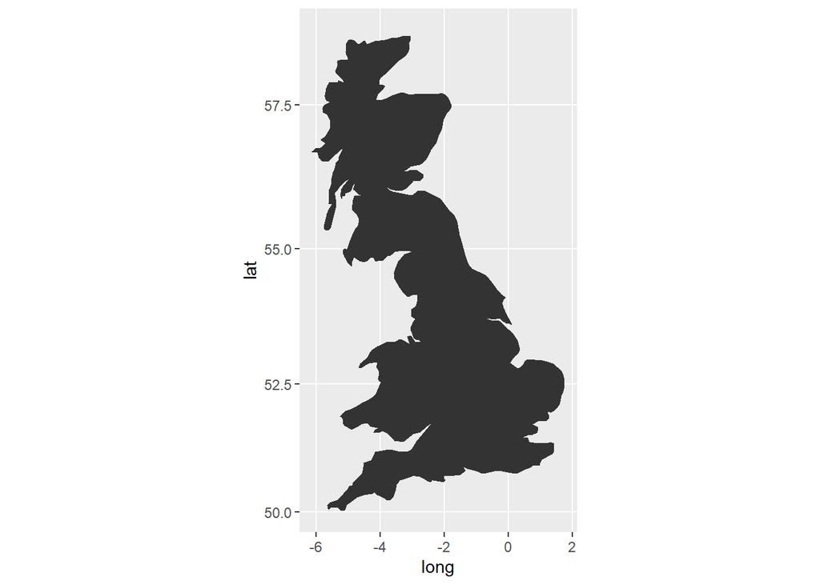

```r
if(!require("dplyr")) {install.packages("dplyr")}
if(!require("ggplot2")) {install.packages("ggplot2")}
if(!require("ggplot2")) {install.packages("maps")}
if(!require("ggplot2")) {install.packages("ggthemes")}
if(!require("ggplot2")) {install.packages("mapproj")}

library(dplyr)
library(maps)
library(ggthemes)
library(mapproj)
library(ggplot2)
## getting map of UK
uk <- map_data("world") %>%
  filter(subregion == "Great Britain")

ggplot(uk, aes(x = long, y = lat, group = group)) +
  geom_polygon() +
  coord_map()
```

Now we should plot the trunk road on the Scotland map so that we can see the trail more clearly. We can found the roads from [shapefile online](https://mapcruzin.com/free-scotland-arcgis-maps-shapefiles.htm) called Scottish roads and it shopuld be useful. We now draw the trail of Scotland on the Britain map we plotted before. As both of the trunk road data and the Britain map use the real world longitude and latitude, we can easily match them together.

```r
## download the appropriate shapefile listed above
## and read in from shape file
library(sf)
```

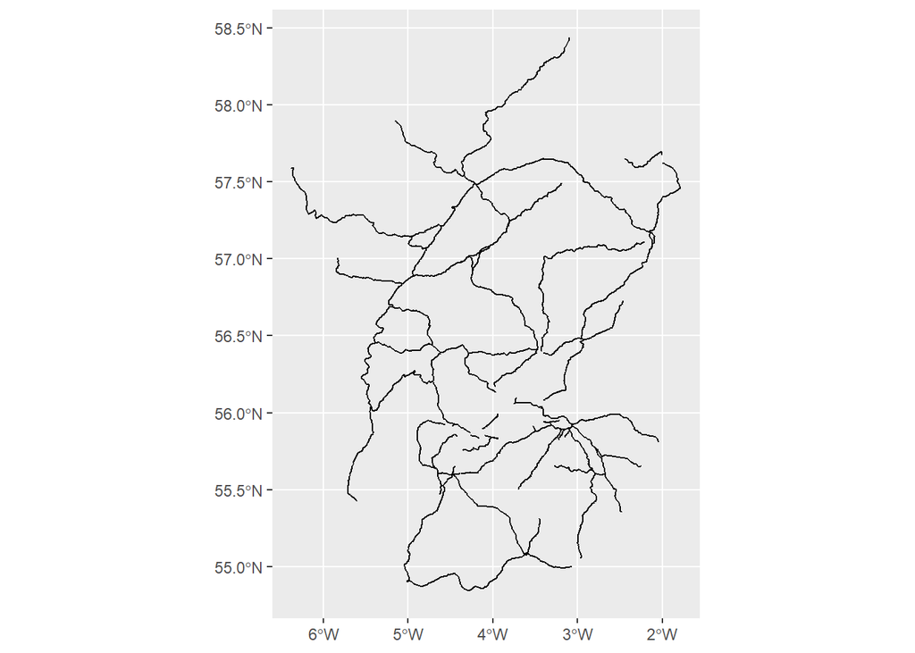

```r
load("C:/Users/OMEN/Desktop/UoA/UoA-4/CS 791/trunk_roads.RData")
ggplot(trunk_roads) + geom_sf()
```

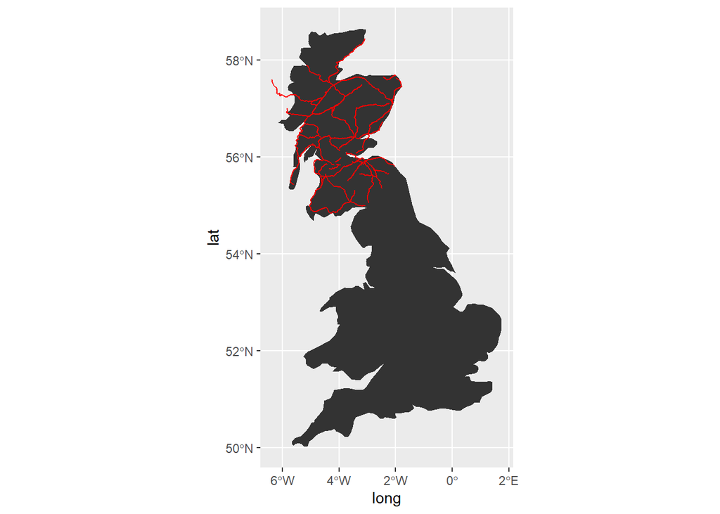

```r
## again these are in lat long, so you need to figure out what coordinates your
## vehicle trails are in
ggplot(uk, aes(x = long, y = lat, group = group)) +
  geom_polygon() +
  coord_map() +
  geom_sf(data = trunk_roads, color = "red", inherit.aes = FALSE)
```

Now write a R function to display the trail on the map for the selected cars. The coordinate system used on the web page represents the current coordinates by two multi-digit numbers, however, the UK map generated by `map_data` function uses the true latitude and longitude. Hence, in order to unify the two coordinate systems, a mathematical approach is used and it can relatively accurately convert the coordinates of the map on the web page into the true latitude and longitude. When moving the mouse on the web page, the coordinates of the cursor position will be displayed in the lower left corner of the web page. So we need to unify the two coordinate systems. Here I use a mathematical method, which can relatively accurately convert the coordinates of the map on the web page into the true latitude and longitude, the corresponding function relationship is in the code comment below. The trail information within 2 hours is stored in the df_total dataframe, the data is sorted by the feature “Vehicle”, thus, we can use `which` function to get the start row and end row for a specific gritter in the dataframe. Then we get the longitude and latitude for the trails of one gritter and use `geom_point()` function to display them on the map.

We can use `unique()` funciton to check which gritters are available for querying, and then use the `select_trail` function to see this the two-hour historic trail for this specific gritter on map.

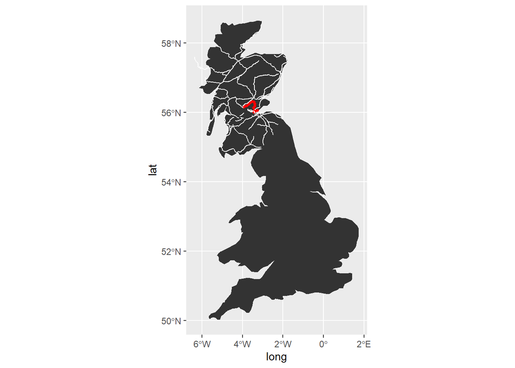

```r
#Coordinate System
#For longitude: Y = -0.000016 * X + 8.43
#For latitude: Y = 0.0000093*X +49.6
#Y is the actual longitude/latitude, X is X-coodinate/Y-coordinate on the web page.

#The function for displaying the trail of the designated gritters in two hours on the map

select_trail = function(Gritter_Vehicle){
  #Find its line position in the df_total dataframe
  start_line = min(which(df_total$Vehicle == Gritter_Vehicle))
  end_line = max(which(df_total$Vehicle == Gritter_Vehicle))
  #get the coordinate on the map
  convert2long = -1 * (-0.000016 * df_total[start_line:end_line,]$X_coord + 8.43)
  convert2lat = 0.0000093 * df_total[start_line:end_line,]$Y_coord + 49.6
  #Use ggplot to draw the trail
  ggplot()+geom_polygon(data=uk, aes(x=long, y=lat, group=group)) +
    geom_point(data=df_total[start_line:end_line,], aes(x=convert2long, y=convert2lat), color = 'red', size = 1.0) +
    geom_sf(data = trunk_roads, color = "white", inherit.aes = FALSE)
}

select_trail("SJ65FVT")
```

## Analysis

We find that the names of the gritters are interesting and we can try to analyze, process, induce and infer the text of their names, so as to study the subjective emotional color of their names. Sentiment analysis is a good option for this target. Sentiment analysis refers to the process of analyzing, processing and extracting subjective text with emotional color by using natural language processing and text mining technology.

The following packages are used in the examples in this article:

- **tm**, for text mining operations like removing numbers, special characters, punctuations and stop words (Stop words in any language are the most commonly occurring words that have very little value for NLP and should be filtered out. Examples of stop words in English are “the”, “is”, “are”.),
- **snowballc**, for stemming, which is the process of reducing words to their base or root form. For example, a stemming algorithm would reduce the words “fishing”, “fished” and “fisher” to the stem “fish”,
- **wordcloud**, for generating the word cloud plot,
- **RcolorBrewer**, for color palettes used in various plots,
- **syuzhet**, for sentiment scores and emotion classification.

```r
library("tm")
```

```r
library("SnowballC")
library("wordcloud")
library("RColorBrewer")
library("syuzhet")
library("tidytext")
```

We extract the Gritter_name from the dataframe that contains the information for all gritters. We use `is.na()` method to delete those missing values. Then, we combine all names into a whole paragraph.

```r
Gritter_name = df$Gritter_name
Gritter_name = Gritter_name[!is.na(Gritter_name)]
Gritter_name_txt = paste(Gritter_name, collapse = " ")
Gritter_name_txt
```

```
## [1] "GRIT LIKE I'DAY GRANITE GRITTER GRITTEST HITS GRITTEST HITS SOPHIE SALT SLIPPY MCGRITTY SPRINKLEBELL SNOW TROOPER SPRINKLES PLOUGHER O' SCOTLAND MRS MCGRITTER SIR ANDY FLURRY THE SNOWCLAIMERS POLAR BEAR EXPRESS MY NAME'5 DODDIE MEGAMELTASAURUS THE SNOW BUSTER GRITTY GRITTY BANG BANG SIR GRIT…
```

```r
# Load the data as a corpus
TextDoc = Corpus(VectorSource(Gritter_name_txt))
# Convert the text to lower case
TextDoc = tm_map(TextDoc, content_transformer(tolower))
# Remove numbers
TextDoc = tm_map(TextDoc, removeNumbers)
# Remove english common stopwords
TextDoc = tm_map(TextDoc, removeWords, stopwords("english"))
# specify your custom stopwords as a character vector
TextDoc = tm_map(TextDoc, removeWords, c("s"))
# Remove punctuations
TextDoc <- tm_map(TextDoc, removePunctuation)
```

After cleaning the text data, the next step is to count the occurrence of each word, to identify popular or trending topics. Using the function TermDocumentMatrix() from the text mining package, you can build a Document Matrix – a table containing the frequency of words.The following table of word frequency is the expected output of the head command on RStudio Console.

```r
# Build a term-document matrix
TextDoc_dtm <- TermDocumentMatrix(TextDoc)
dtm_m <- as.matrix(TextDoc_dtm)
# Sort by decreasing value of frequency
dtm_v <- sort(rowSums(dtm_m),decreasing=TRUE)
dtm_d <- data.frame(word = names(dtm_v),freq=dtm_v)
# Display the top 5 most frequent words
head(dtm_d, 5)
```

```
##            word freq
## snow       snow    7
## sir         sir    6
## bear       bear    5
## gritter gritter    5
## gritty   gritty    5
```

Plotting the top 5 most frequent words using a bar chart is a good basic way to visualize this word frequent data. They are ‘snow’, ‘sir’, ‘bear’, ‘gritter’ and ‘gritty’. We know that gritter is a vehicle or machine for spreading grit and often salt on roads in icy or potentially icy weather. So it makes senese that the word with highest frequency in the names is ‘snow’.

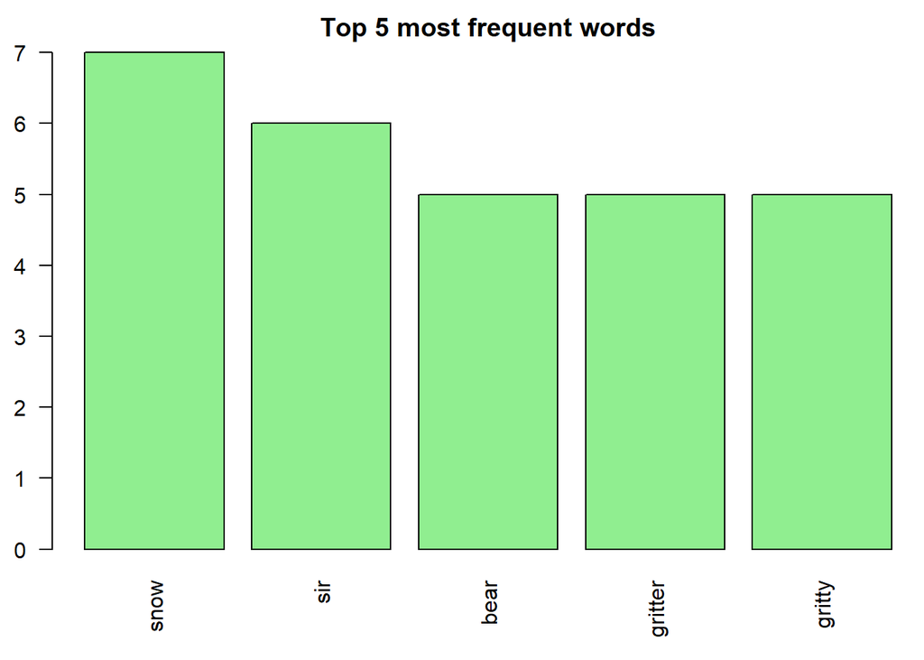

```r
par(mar = c(4, 2, 2, 0))
barplot(dtm_d[1:5,]$freq, las = 2, names.arg = dtm_d[1:5,]$word,
        col ="lightgreen", main ="Top 5 most frequent words",
        ylab = "Word frequencies")
```

Now, let’s generate a word cloud. A word cloud is one of the most popular ways to visualize and analyze qualitative data. It’s an image composed of keywords found within a body of text, where the size of each word indicates its frequency in that body of text. Use the word frequency data frame (table) created previously to generate the word cloud.

Below is a brief description of the arguments in the word cloud function:

- **words**, words to be plotted,
- **freq**, frequencies of words,
- **min.freq**, words whose frequency is at or above this threshold value is plotted,
- **max.words**, the maximum number of words to display on the plot,
- **randon.order**, I have set it to FALSE, so the words are plotted in order of decreasing frequency,
- **rot.per**, the percentage of words that are displayed as vertical text (with 90-degree rotation),
- **colors**, hanges word colors going from lowest to highest frequencies.

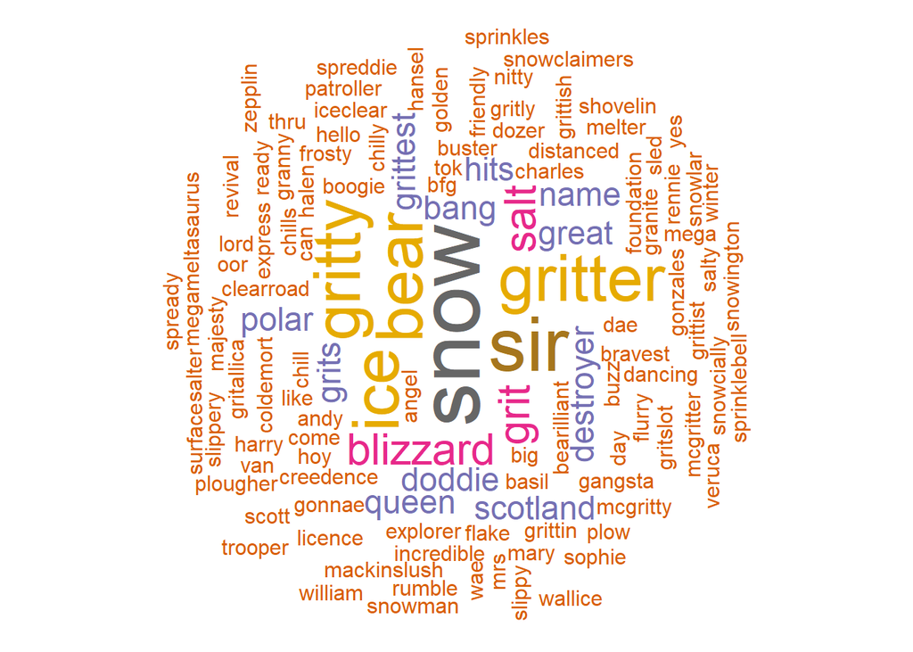

```r
#generate word cloud
set.seed(040)
par(mar = c(0,0,0,0))
wordcloud(words = dtm_d$word, freq = dtm_d$freq, min.freq = 1,
          max.words=500, random.order=FALSE, rot.per=0.40,
          colors=brewer.pal(8, "Dark2"))
```

Emotion classification is built on the NRC Word-Emotion Association Lexicon (aka EmoLex). The definition of “NRC Emotion Lexicon”, sourced from http://saifmohammad.com/WebPages/NRC-Emotion-Lexicon.htm is “The NRC Emotion Lexicon is a list of English words and their associations with eight basic emotions (anger, fear, anticipation, trust, surprise, sadness, joy, and disgust) and two sentiments (negative and positive). The annotations were manually done by crowdsourcing.”

```r
d <- get_nrc_sentiment(Gritter_name_txt)
# head(d,10) - to see top 10 lines of the get_nrc_sentiment dataframe
head (d,10)
```

```
##   anger anticipation disgust fear joy sadness surprise trust negative positive
## 1     4            5       2    4   3       2        2     6        6        8
```

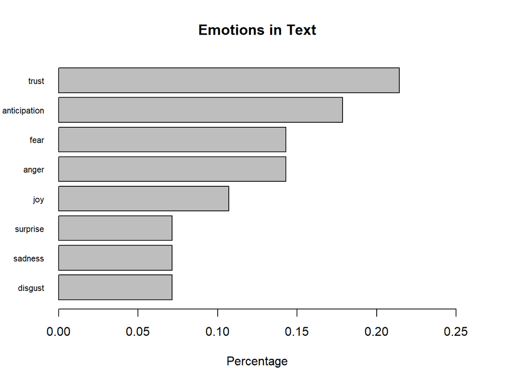

```r
par(mar = c(4, 4, 4, 4))
barplot(
  sort(colSums(prop.table(d[, 1:8]))),
  horiz = TRUE,
  cex.names = 0.7,
  las = 1,
  xlim=c(0,0.25),
  main = "Emotions in Text", xlab="Percentage"
)
```